# Slice sampler

Jaeyong Lee

2023-06-27

[Reference](https://www.jarad.me/courses/stat615/slides/Slice/slice.pdf)

```r
library(progress)
```

## Example 1

Sample from the standard normal density,

$$f(x) \propto \mathrm{exp}(-x^2/2), ~~ -\infty < x < \infty.$$

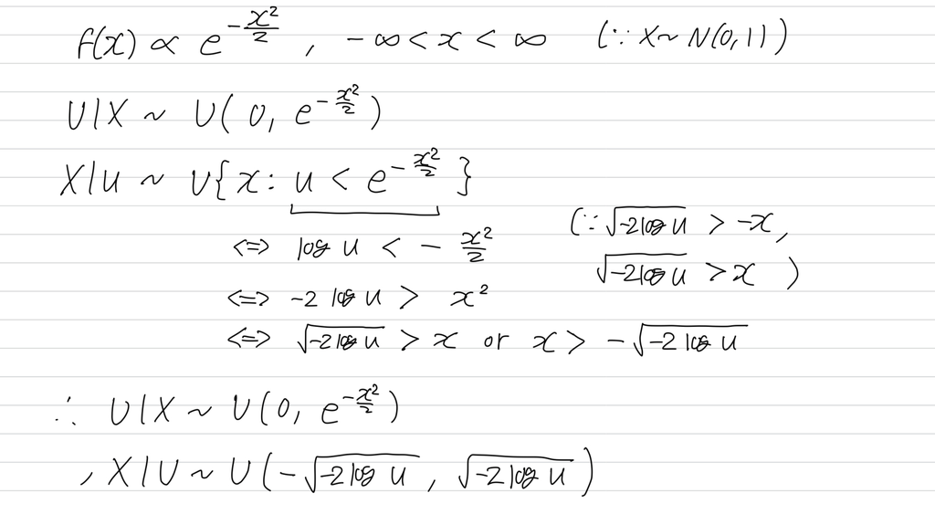

```r
set.seed(0)

# total number of iterations for slice sampler
N = 10000

# initializing the space for the samples
us = rep(1, N)  # auxiliary variable
xs = rep(1, N)

# slice sampler
for(i in 2:N){
  us[i] = runif(1, min = 0, max = exp(-0.5*(xs[i-1]^2)))
  xs[i] = runif(1, min = -sqrt(-2*log(us[i])), max = sqrt(-2*log(us[i])))
}
```

```r
true = seq(-5, 5, 0.01)
true_f = dnorm(true)

hist(xs, freq=F, breaks=200, main = "Histogram of slice samples", xlab = "x")
lines(true, true_f, type="l", col="red")
```

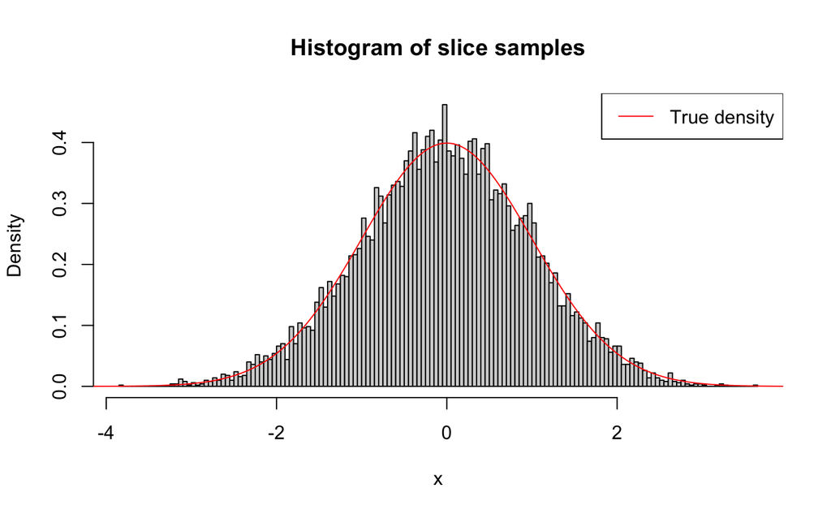

```r
legend("topright", legend = "True density", col = "red", lty = 1)
```

## Example 2

Sample from exponential(1),

$$f(x) \propto \mathrm{exp}(-x), ~~ 0 < x < \infty.$$

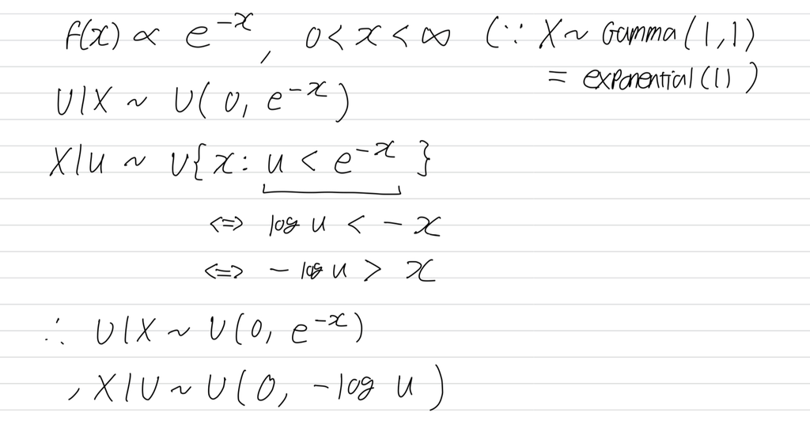

```r
set.seed(0)

# total number of iterations for slice sampler
N = 10000

# initializing the space for the samples
us = rep(1, N)  # auxiliary variable
xs = rep(1, N)

# slice sampler
for(i in 2:N){
  us[i] = runif(1, min = 0, max = exp(-xs[i-1]))
  xs[i] = runif(1, min = 0, max = -log(us[i]))
}
```

```r
true = seq(0, 10, 0.01)
true_f = dgamma(true, shape = 1, scale = 1)

hist(xs, freq=F, breaks=200, main = "Histogram of slice samples", xlab=expression(x))
lines(true, true_f, type="l", col="red")
```

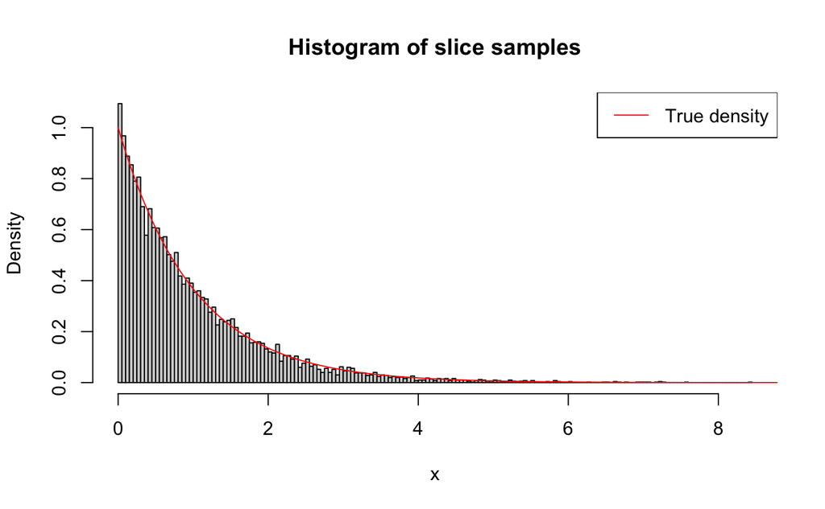

```r
legend("topright", legend = "True density", col = "red", lty = 1)
```

## Example 3 (Numerical method)

Let $Y_i \overset{ind}{\sim} N(\theta, 1)$ and $\theta \sim \mathrm{exp}(1)$. Then,

$$P(\theta|y) \propto \prod_{i=1}^{n} \left [ N(y_i; \theta, 1) \right ]
\mathrm{exp}(\theta; 1).$$

Let $\theta = 0.2$. Since it is hard to derive the inverse function for the slice sampler from,

$$\begin{aligned}
u|\theta &\sim U(0, P(\theta|y)), \\
\theta|u &\sim U \left \{ \theta: u < P(\theta|y) \right \},
\end{aligned}$$

we solve it numerically using the function uniroot() for the two end points of $\theta$.

```r
set.seed(0)

### Observations
n = 500
true_theta = 0.2
y = rnorm(n, mean = true_theta, sd = 1)

### PDF of the posterior dstn
f = function(theta, y. = y){
    exp(sum(dnorm(y., mean = theta, sd = 1, log = TRUE)) + dexp(abs(theta), log = TRUE))
}

### Function to numerically find endpoints
A = function(u, xx, f. = f){
  left_endpoint = uniroot(function(x) f.(x) - u, c(-10^10, xx))
  right_endpoint = uniroot(function(x) f.(x) - u, c(10^10, xx))
  return(c(left_endpoint$root, right_endpoint$root))
}
```

```r
### Slice sampler
slice_sampler = function(N, init_theta, target, A){
  ## Initialization
  u = rep(NA, N)
  theta = rep(NA, N)
  theta[1] = init_theta
  u[1] = runif(1, 0, target(theta[1]))

  pb = progress_bar$new(
    format = "  MCMC [:bar] :percent eta: :eta",
    total = N-1, clear = FALSE, width= 60)

  ## MCMC algorithm iterations
  for(i in 2:N){
    pb$tick()

    u[i] = runif(1, 0, target(theta[i-1]))
    endpoints = A(u[i], theta[i-1])
    theta[i] = runif(1, endpoints[1], endpoints[2])
  }

  return(theta)
}
```

```r
set.seed(0)

N = 5000  # number of iterations for the MCMC algorithm
ptm = proc.time()  # to time the algorithm
theta = slice_sampler(N, mean(y), f, A)
```

```r
proc.time() - ptm
```

```
   user  system elapsed
 15.960   0.537  19.359
```

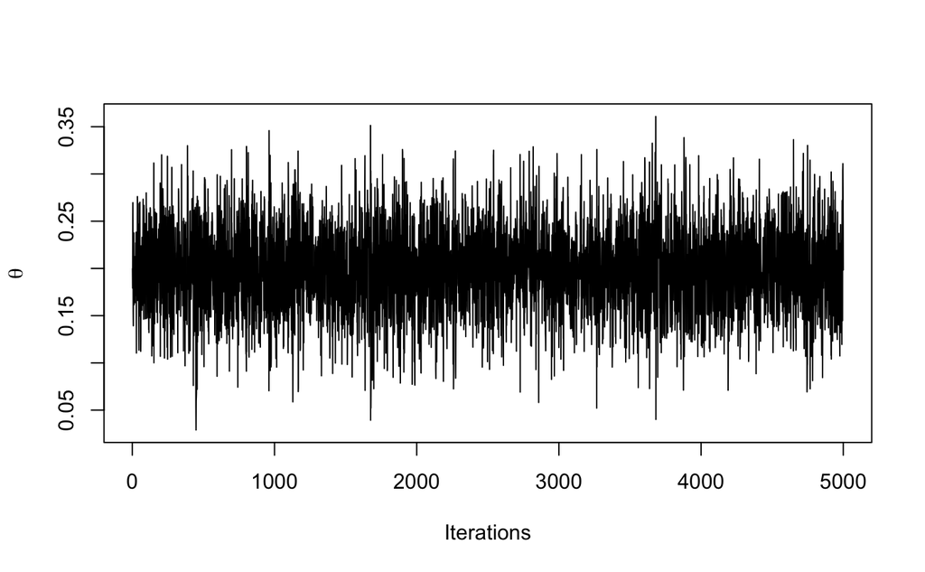

```r
### Traceplot
plot(1:N, theta, type = "l", xlab = "Iterations", ylab = expression(theta))
```

```r
### Posterior mean
mean(theta)
```

```
[1] 0.1980653
```

## Example 4 (Augmentation method)

Let $Y_i \overset{ind}{\sim} N(\theta, 1)$ and $\theta \sim \mathrm{exp}(1)$. Then,

$$P(\theta|y) \propto \prod_{i=1}^{n} \left [ N(y_i; \theta, 1) \right ]
\mathrm{exp}(\theta; 1).$$

Unlike example 3, we will now use augmentation,

$$P(u, \theta) \propto P(\theta)I(0 < u < P(y|\theta)).$$

The full conditional distributions are now,

$$\begin{aligned}
u|\theta, y &\sim U(0, P(y|\theta)), \\
\theta|u, y &\sim P(\theta)I(u < P(y|\theta)).
\end{aligned}$$

If $P(\theta)$ is unimodal, the conditional dstn for $\theta|u, y$ is equivalent to

$$P(\theta)I(\theta_L(u) < \theta < \theta_U(u)),$$

for some bounds $\theta_L(u)$ and $\theta_U(u)$ which depend on $u$. To learn these bounds we can sample from $P(\theta)$ and update the bounds. For example, if $\theta^{(t-1)}$ is our current value in the chain, we know $u < P(y|\theta^{(t-1)})$, or equivalently,

$$\theta_L(u) < \theta^{(t-1)} < \theta_U(u).$$

Letting $u^{(t)}$ be the current value for the auxiliary variable and setting $\theta_L(u^{(t)})$ and $\theta_U(u^{(t)})$ for the lower and upper bounds of the support for $\theta$ respectively, the slice sampler algorithm goes as follows.

For $t = 1, ..., T$,

1. Sample $\theta^*$ from

$$\theta^* \sim P(\theta)I(\theta_L(u^{(t)}) < \theta <
\theta_U(u^{(t)})).$$

2. Set $\theta^{(t)} = \theta^*$ if

$$u^{(t)} < P(y|\theta^*),$$

otherwise set

$$\begin{aligned}
\theta_L(u^{(t)}) &= \theta^* ~~ \mathrm{if} ~~ \theta^* <
\theta^{(t-1)}, \\
\theta_U(u^{(t)}) &= \theta^* ~~ \mathrm{if} ~~ \theta^* >
\theta^{(t-1)},
\end{aligned}$$

and return to Step (1).

```r
### Slice sampler
aug_slice_sampler = function(N, init_theta, like, qprior){
  ## Initialization
  u = rep(NA, N)
  theta = rep(NA, N)
  theta[1] = init_theta
  u[1] = runif(1, 0, like(theta[1]))

  pb = progress_bar$new(
    format = "  MCMC [:bar] :percent eta: :eta",
    total = N-1, clear = FALSE, width= 60)

  ## MCMC algorithm iterations
  for (i in 2:N){
    pb$tick()

    u[i] = runif(1, 0, like(theta[i - 1]))
    success = FALSE
    endpoints = 0:1

    while(!success){
    # Inverse CDF
    up = runif(1, endpoints[1], endpoints[2])
    theta[i] = qprior(up)
    if (u[i] < like(theta[i])) {
      success = TRUE
    } else {
      if(theta[i] < theta[i - 1]){endpoints[1] = up}
      else{endpoints[2] = up}
      }
    }
  }
  return(theta)
}
```

```r
set.seed(0)

### Observations
n = 500
true_theta = 0.2
y = rnorm(n, mean = true_theta, sd = 1)

### Likelihood function for a given theta
like = function(tht) exp(sum(dnorm(y, mean = tht, sd = 1, log = TRUE)))

### inverse CDF of prior
qprior = function(tht) qexp(tht)
```

```r
set.seed(0)

N = 5000  # number of iterations for the MCMC algorithm
ptm = proc.time()  # to time the algorithm
theta = aug_slice_sampler(N, mean(y), like, qprior)
```

```r
proc.time() - ptm
```

```
   user  system elapsed
  5.552   0.289   8.261
```

We can see that this is much faster than the slice sampler with numerical method.

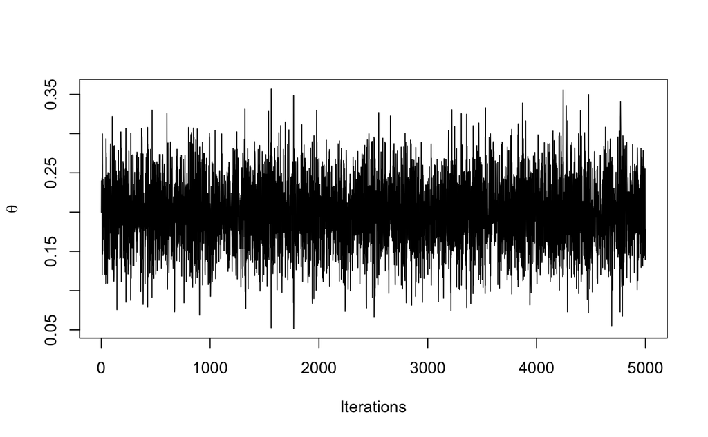

```r
### Traceplot
plot(1:N, theta, type = "l", xlab = "Iterations", ylab = expression(theta))
```

```r
### Posterior mean
mean(theta)
```

```
[1] 0.1984192
```